# Impact of University Majors on Employment of Recent Graduates

Sudip Das

2024-12-05

## 1. Introduction

As a graduate student in the United States, I have experienced firsthand how challenging it can be to secure a job in the current market. This struggle is shared by many students, who often feel uncertain about their prospects after graduation. While the economic conditions may fluctuate over time, examining data from recent graduates can provide valuable insights into employment trends and factors that have contributed to successful outcomes in the past. By understanding these patterns, current and future graduates can make more informed decisions about their career paths and expected earnings.

This project aims to answer several important research questions related to career outcomes, gender disparities, and economic trends among recent graduates. Specifically, the analysis aims to determine which majors offer the best prospects for employment and salary. This involves analyzing the average and median salaries across different majors, examining unemployment rates, and assessing the availability of full-time versus part-time positions. It also identifies whether certain departments, such as STEM, Arts, or Business, consistently provide better outcomes for graduates. Furthermore, it examines whether there is a relationship between median salary and unemployment rate.

Another focus of this project is to explore gender disparities in the US education system. It will examine not only the number of male and female graduates in each major but also their income levels after graduation, to determine whether gender plays a role in career outcomes. Additionally, we aim to assess if gender influences the choice of specific majors, potentially impacting long-term economic prospects.

Overall, this analysis aims to provide a deeper understanding of the factors that influence graduates’ success in the job market and help prospective students make informed decisions about their education paths. By highlighting the relationship between field of study and employment security, the project hopes to shed light on which fields may offer greater stability and which graduates may be at higher risk of underemployment. Ultimately, the goal is to contribute to the ongoing discussion about the economic value of college degrees and provide meaningful insights for students, educators, and policymakers.

## 2. Related Work

Prior research, such as Carnevale et al.’s report “What’s It Worth?: The Economic Value of College Majors,” offers a foundational framework for understanding the economic outcomes of various college majors. This report highlights disparities in employment and salary outcomes across disciplines, emphasizing the importance of examining major-specific trends. Link to article: http://cew.georgetown.edu/whatsitworth

This project is using data from recent graduates only. Similarly there is more work done and data collected for students currently attending university and women in STEM by the FiveThirtyEight site. Link to dataset: https://github.com/fivethirtyeight/data/tree/master/college-majors

## 3. Data

### 3.1 Dataset Overview

The dataset was collected from the American Community Survey (ACS) conducted between 2010 and 2012, specifically from the ‘Public Use Microdata Series’. This data is based on the outcomes of individuals who have recently graduated, offering a snapshot of employment and salary outcomes for graduates from different fields of study.

The dataset is part of the ’FiveThirtyEight” site which is a popular interactive news and sports site started by Nate Silver. It is available on github and can be accessed through this link: https://github.com/fivethirtyeight/data/blob/master/college-majors/recent-grads.csv

The dataset includes key information such as:

- College majors (computer engineering, finance etc)
- Major categories (Engineering, Arts etc)
- Total graduates (further separated into men and women)
- Employment statistics (unemployment rate, full-time, part-time etc)
- Earnings data (Median salary, percentiles)
- Job type (low wage jobs, college jobs)
- Rank (based on median earnings)

The college majors from the dataset along with their codes are categorized based on the information from Georgetown University Center on Education. More details can be found through this article: http://cew.georgetown.edu/whatsitworth

The data was collected as part of an observational study, rather than through an experiment, as it describes the real-world outcomes of graduates in the job market.

### 3.2 Dataset Observations

```r
# Import Dataset
indata <- read.csv("/Users/sudipdas/Desktop/recent-grads.csv")

# Check data
head(indata,5)
```

```
##   Rank Major_code                                     Major Total   Men Women
## 1    1       2419                     PETROLEUM ENGINEERING  2339  2057   282
## 2    2       2416            MINING AND MINERAL ENGINEERING   756   679    77
## 3    3       2415                 METALLURGICAL ENGINEERING   856   725   131
## 4    4       2417 NAVAL ARCHITECTURE AND MARINE ENGINEERING  1258  1123   135
## 5    5       2405                      CHEMICAL ENGINEERING 32260 21239 11021
##   Major_category ShareWomen Sample_size Employed Full_time Part_time
## 1    Engineering  0.1205643          36     1976      1849       270
## 2    Engineering  0.1018519           7      640       556       170
## 3    Engineering  0.1530374           3      648       558       133
## 4    Engineering  0.1073132          16      758      1069       150
## 5    Engineering  0.3416305         289    25694     23170      5180
##   Full_time_year_round Unemployed Unemployment_rate Median P25th  P75th
## 1                 1207         37        0.01838053 110000 95000 125000
## 2                  388         85        0.11724138  75000 55000  90000
## 3                  340         16        0.02409639  73000 50000 105000
## 4                  692         40        0.05012531  70000 43000  80000
## 5                16697       1672        0.06109771  65000 50000  75000
##   College_jobs Non_college_jobs Low_wage_jobs
## 1         1534              364           193
## 2          350              257            50
## 3          456              176             0
## 4          529              102             0
## 5        18314             4440           972
```

```r
dim(indata)
```

```
## [1] 173  21
```

The dimensions are checked to be 173,21; which corresponds to 173 observations (rows) and 21 variables (columns). Here, each row represents an unique major, providing detailed information about the graduates within that field, such as their earnings, employment status, and gender distribution.

The numerical variables in the dataset are Total, Rank, Men, Women, ShareWomen, Sample_Size, Employed, Full_time, Part_time, Full_time_year_round, Unemployed, Unemployment_rate, Median, P25th, P75th, College_jobs, Non_college_jobs and Low_wage_jobs.

The categorical columns are major_code, major and major_category. Although major_code is represented by integers, it can be considered as a category as it represents the majors.

Out of the 21 variables, it would not be ideal to remove any columns, as each has its own significance and can be used in different parts of the analysis. However, some columns can be grouped or derived from others. For instance, the variables Major Code and Major both represent the same information but in different formats, which could be used together for reference. Similarly, the Total number of graduates can be derived by summing the Men and Women columns. These relationships between variables provide flexibility in our analysis, allowing us to examine both detailed and aggregated information to draw meaningful conclusions. Therefore all the columns would be used in this project.

### 3.3 Data Quality

```r
# Import library
library(tidyverse)
# Check for missing values
missing_values <- colSums(is.na(indata))
missing_values
```

```
##                 Rank           Major_code                Major
##                    0                    0                    0
##                Total                  Men                Women
##                    1                    1                    1
##       Major_category           ShareWomen          Sample_size
##                    0                    1                    0
##             Employed            Full_time            Part_time
##                    0                    0                    0
## Full_time_year_round           Unemployed    Unemployment_rate
##                    0                    0                    0
##               Median                P25th                P75th
##                    0                    0                    0
##         College_jobs     Non_college_jobs        Low_wage_jobs
##                    0                    0                    0
```

Based on the missing values, it looks the data is quite complete and has no significant issue except for 1 missing value in Total, Men, Women and ShareWomen columnns. These missing values are minor, but it is essential to address them to ensure data consistency and reliability for analysis.

```r
# Identify rows with missing values
missing_rows <- indata %>% filter(is.na(Total) | is.na(Men) | is.na(Women) | is.na(ShareWomen))

missing_rows
```

```
##   Rank Major_code        Major Total Men Women                  Major_category
## 1   22       1104 FOOD SCIENCE    NA  NA    NA Agriculture & Natural Resources
##   ShareWomen Sample_size Employed Full_time Part_time Full_time_year_round
## 1         NA          36     3149      2558      1121                 1735
##   Unemployed Unemployment_rate Median P25th P75th College_jobs Non_college_jobs
## 1        338        0.09693146  53000 32000 70000         1183             1274
##   Low_wage_jobs
## 1           485
```

The first step to handle the data is to check whether the missing values are all part of the same row or is it more than 1 row. The output shows that it is all from the same row and hence this one row can just be dropped without affecting the quality of the dataset.

```r
# Drop the row with missing values
indata <- indata %>% filter(!is.na(Total))
missing_values <- colSums(is.na(indata))
missing_values
```

```
##                 Rank           Major_code                Major
##                    0                    0                    0
##                Total                  Men                Women
##                    0                    0                    0
##       Major_category           ShareWomen          Sample_size
##                    0                    0                    0
##             Employed            Full_time            Part_time
##                    0                    0                    0
## Full_time_year_round           Unemployed    Unemployment_rate
##                    0                    0                    0
##               Median                P25th                P75th
##                    0                    0                    0
##         College_jobs     Non_college_jobs        Low_wage_jobs
##                    0                    0                    0
```

```r
dim(indata)
```

```
## [1] 172  21
```

The single row is then dropped. In the filter condition only the column ‘Total’ is used. Any combination of the 4 columns would have provided the same result as the missing values belong to the same row.

The missing value check then ensures that there are no more missing values and the dimension check confirms that only 1 row was removed.

```r
# Check for duplicate data
unique_major_code <- n_distinct(indata$Major_code)
unique_major <- n_distinct(indata$Major)

unique_major_code
```

```
## [1] 172
```

```r
unique_major
```

```
## [1] 172
```

The total number of major codes and majors match with the total observations in the dataset. This confirms there are no duplicate values and the data was well prepared for further data analysis.

## 4. Exploratory Data Analysis

### 4.1 Earnings Across Different Major Categories

```r
# Load necessary library
library(ggplot2)
library(dplyr)

num_categories <- n_distinct(indata$Major_category)
num_categories
```

```
## [1] 16
```

There are a total of 16 unique major categories across the 172 different majors selected by students.

```r
# Group by Major_category and calculate the mean of Median column
earning_by_category <- indata %>%
  group_by(Major_category) %>%
  summarise(Mean_of_median_earning = mean(Median)) %>%
  arrange(desc(Mean_of_median_earning))

earning_by_category
```

```
## # A tibble: 16 × 2
##    Major_category                      Mean_of_median_earning
##    <chr>                                                <dbl>
##  1 Engineering                                         57383.
##  2 Business                                            43538.
##  3 Computers & Mathematics                             42745.
##  4 Law & Public Policy                                 42200
##  5 Physical Sciences                                   41890
##  6 Social Science                                      37344.
##  7 Health                                              36825
##  8 Biology & Life Science                              36421.
##  9 Industrial Arts & Consumer Services                 36343.
## 10 Agriculture & Natural Resources                     35111.
## 11 Interdisciplinary                                   35000
## 12 Communications & Journalism                         34500
## 13 Arts                                                33062.
## 14 Education                                           32350
## 15 Humanities & Liberal Arts                           31913.
## 16 Psychology & Social Work                            30100
```

Each major category is grouped together and their median earnings are averaged to understand the salary compensation across the different departments. The summary provides a clear view of the financial prospects associated with the popular fields of study.

Engineering leads with a significant margin, with a median earning of $57,383. This aligns with general expectations that technical and specialized fields such as engineering often offer higher salaries due to high demand and specialized skill requirements.

Departments such as Business, Computers & Mathematics, Law and Physical Sciences come after Engineering with a estimated earning prospect of between 41,000 to 43,000. Fields such as Arts, Education, Humanities & Liberal Arts, and Psychology & Social Work are at the bottom of the earnings spectrum, with earnings between 30,100 and 33,000.

This table shows that fields in STEM (Science, Technology, Engineering, and Mathematics) generally offer better financial outcomes.

### 4.2 Low Wage Jobs Percentage Across Major Categories

Although the mean earning across departments provide a good comparison, students should also check the ratio of graduates working low wage jobs due to job unavailability and market conditions.

```r
# Add the new column and calculate low wage jobs percentage
indata <- indata %>%
  mutate(low_wage_jobs_percent = (Low_wage_jobs / Employed) * 100)

weighted_low_wage_jobs_by_category <- indata %>%
  group_by(Major_category) %>%
  summarise(
    total_sample_size = sum(Sample_size, na.rm = TRUE),
    weighted_low_wage_jobs_percent = sum(low_wage_jobs_percent * Sample_size, na.rm = TRUE) / total_sample_size
  ) %>%
  arrange(weighted_low_wage_jobs_percent)

weighted_low_wage_jobs_by_category
```

```
## # A tibble: 16 × 3
##    Major_category                      total_sample_size weighted_low_wage_job…¹
##    <chr>                                           <int>                   <dbl>
##  1 Engineering                                      4926                    5.87
##  2 Health                                           3914                    6.64
##  3 Computers & Mathematics                          2860                    6.78
##  4 Education                                        4742                    8.39
##  5 Physical Sciences                                1137                   10.4
##  6 Interdisciplinary                                 128                   10.8
##  7 Agriculture & Natural Resources                  1068                   11.5
##  8 Business                                        15505                   11.7
##  9 Industrial Arts & Consumer Services              2165                   13.4
## 10 Social Science                                   4581                   13.4
## 11 Biology & Life Science                           2317                   14.2
## 12 Law & Public Policy                              1935                   14.4
## 13 Psychology & Social Work                         3180                   14.8
## 14 Communications & Journalism                      4508                   15.0
## 15 Humanities & Liberal Arts                        5340                   17.2
## 16 Arts                                             3260                   20.6
## # ℹ abbreviated name: ¹weighted_low_wage_jobs_percent
```

First, a new column is added which represents the percentage of graduates in low wage jobs for every major. This is calculated by dividing the number of low wage graduates by the total employed graduates for that major. Second, the total sample size is calculated for every category. This is important to understand the weight of each major in the dataset as the size of data collected for every major is different. Next, instead of obtaining the mean, the weighted average is taken by multiplying the low wage percentage with its sample size.

The table shows that departments such as Engineering (5.87%) and Health (6.64%) have the lowest weighted percentage of low paying jobs. These fields generally offer higher-paying opportunities and reflects a strong demand for specialized, high-skill roles. Fields such as Humanities & Liberal Arts (17.2%) and Arts (20.6%) have the highest weighted percentages of low-wage jobs. Graduates in these fields may face more challenges in finding well-paying positions. The results further display the financial benefits of STEM careers.

### 4.3 Unemployment Rates Across Major Categories

The total compensation of a department after graduation is not the only thing that would make the field suitable for everything. In addition to checking earning, there are important features such as unemployment rates.

```r
unemployment_by_category <- indata %>%
  group_by(Major_category) %>%
  summarise(Mean_Unemployment_Rate = mean(Unemployment_rate)) %>%
  arrange(Mean_Unemployment_Rate)

unemployment_by_category
```

```
## # A tibble: 16 × 2
##    Major_category                      Mean_Unemployment_Rate
##    <chr>                                                <dbl>
##  1 Physical Sciences                                   0.0465
##  2 Industrial Arts & Consumer Services                 0.0481
##  3 Education                                           0.0517
##  4 Agriculture & Natural Resources                     0.0518
##  5 Biology & Life Science                              0.0609
##  6 Engineering                                         0.0633
##  7 Health                                              0.0659
##  8 Interdisciplinary                                   0.0709
##  9 Business                                            0.0711
## 10 Psychology & Social Work                            0.0721
## 11 Communications & Journalism                         0.0755
## 12 Humanities & Liberal Arts                           0.0810
## 13 Computers & Mathematics                             0.0843
## 14 Arts                                                0.0902
## 15 Law & Public Policy                                 0.0908
## 16 Social Science                                      0.0957
```

The table shows that Physical Sciences (4.65%) and Industrial Arts & Consumer Services (4.81%) have the lowest mean unemployment rates, indicating higher job stability and demand within these fields. Arts (9.02%), Law & Public Policy (9.08%), and Social Science (9.57%) exhibit the highest unemployment rates, suggesting challenges in job placement or sector-specific economic fluctuations. This could reflect market saturation or limited high-paying opportunities in these fields during that time period of the data collection.

This analysis highlights that fields with high unemployment rates may require proactive career planning, including internships, networking, and possibly cross-disciplinary skills. However, this data may vary as trends often change over time.

#### BoxPlot

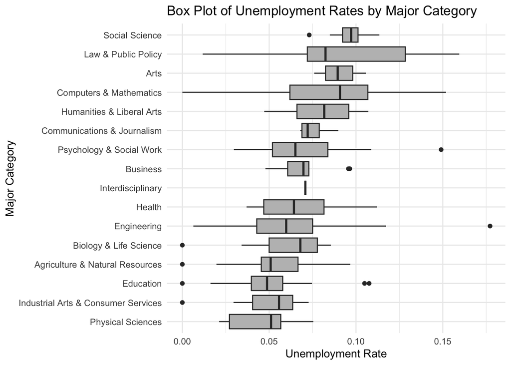

```r
# Box plot for Unemployment_rate by Major_category
ggplot(indata, aes(y = reorder(Major_category, Unemployment_rate), x = Unemployment_rate)) +
  geom_boxplot(fill = "gray") +
  labs(
    title = "Box Plot of Unemployment Rates by Major Category",
    x = "Unemployment Rate",
    y = "Major Category"
  ) +
  theme_minimal()
```

The box plot visualizes the unemployment rates across different major categories along with the outliers and the variations within the categories. Fields such as Law & Public Policy, and Computers & Mathematics show substantial variability implies that while some subfields may have lower unemployment rates, others experience higher rates, leading to a wide range. The plots also shows some outliers with a unemployment rate of 0. This particular fields within the category would be highly favourable for students who prioritize job security.

#### Scatter Plot

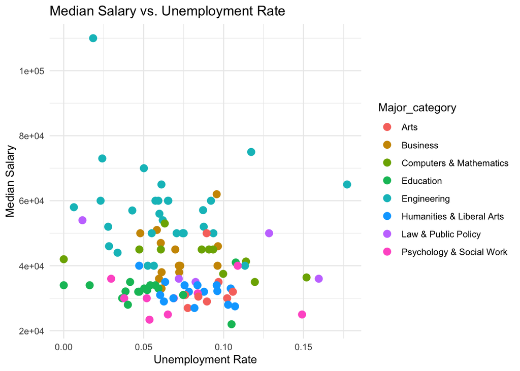

```r
# Get top 4 and bottom 4 by earning
top_bottom_categories <- earning_by_category %>%
  slice(c(1:4, (n()-3):n()))

# Filter the original data to include only the selected top and bottom categories
filtered_data <- indata %>%
  filter(Major_category %in% top_bottom_categories$Major_category)

ggplot(filtered_data, aes(x = Unemployment_rate, y = Median, color = Major_category)) +
  geom_point(size = 3) +
  labs(
    title = "Median Salary vs. Unemployment Rate",
    x = "Unemployment Rate",
    y = "Median Salary"
  ) +
  theme_minimal()
```

The scatter plot displays the trends in median salary vs unemployment rate. The top 4 highest and 4 lowest earning departments are used for this plot to reduce the amount of points and make the plot more understandable.

Engineering stands out with several data points clustered around higher median salaries and lower unemployment rates. This suggests that engineering fields provide not only high financial returns but also relatively stable employment opportunities. Overall unemployment rates vary significantly within categories and don’t provide a definitive trend. However, it also shows that students can avoid low earning careers as unemployment rate can also be high for a lower paid job.

### 4.4 Popular Majors for Graduate Students

Prospective tudents can benefit from looking into the popularity of majors before choosing their own major while university recruitement and planner can benefit from understanding what departments need more faculties and what fields need more promotion.

```r
# Top 5 most popular majors by Total
most_popular_majors <- indata %>%
  arrange(desc(Total)) %>%
  select(Major, Total) %>%
  head(5)
most_popular_majors
```

```
##                                    Major  Total
## 1                             PSYCHOLOGY 393735
## 2 BUSINESS MANAGEMENT AND ADMINISTRATION 329927
## 3                                BIOLOGY 280709
## 4                       GENERAL BUSINESS 234590
## 5                         COMMUNICATIONS 213996
```

```r
# Least 5 popular majors by Total
least_popular_majors <- indata %>%
  arrange(Total) %>%
  select(Major, Total) %>%
  head(5)

least_popular_majors
```

```
##                                    Major Total
## 1                  MILITARY TECHNOLOGIES   124
## 2       MATHEMATICS AND COMPUTER SCIENCE   609
## 3                           SOIL SCIENCE   685
## 4 GEOLOGICAL AND GEOPHYSICAL ENGINEERING   720
## 5         MINING AND MINERAL ENGINEERING   756
```

Military Technologies is the least popular major, with only 124 graduates. This specialized field likely appeals to a small, targeted group, such as those pursuing careers in defense and military operations only. Majors such as Soil Science and Geological and Geophysical Engineering tend to be more niche while offerring less jobs. However, it doesn’t mean that these fields should be avoided as further analysis is required. Niche jobs tend to have lower competition in the job market leading to less stress and higher pay.

The most popular majors tend to be broad and flexible, providing students with multiple career paths. In contrast, the least popular majors are specialized, attracting only a small number of students with specific interests in niche fields. High-enrollment fields like Psychology and Business may reflect a perception of strong job prospects or broad applicability in the job market. Meanwhile, fields like Military Technologies and Mining Engineering may be less well-known or perceived as having limited career opportunities.

### 4.5 Gender Disparities in Major

```r
gender_summary <- indata %>%
  group_by(Major_category) %>%
  summarise(
    Sum_Total = sum(Total, na.rm = TRUE),
    Sum_Men = sum(Men, na.rm = TRUE),
    Sum_Women = sum(Women, na.rm = TRUE)
  ) %>%
  mutate(Percentage_Women = (Sum_Women / Sum_Total) * 100) %>%
  arrange(Percentage_Women)

gender_summary
```

```
## # A tibble: 16 × 5
##    Major_category                   Sum_Total Sum_Men Sum_Women Percentage_Women
##    <chr>                                <int>   <int>     <int>            <dbl>
##  1 Engineering                         537583  408307    129276             24.0
##  2 Computers & Mathematics             299008  208725     90283             30.2
##  3 Agriculture & Natural Resources      75620   40357     35263             46.6
##  4 Physical Sciences                   185479   95390     90089             48.6
##  5 Business                           1302376  667852    634524             48.7
##  6 Law & Public Policy                 179107   91129     87978             49.1
##  7 Social Science                      529966  256834    273132             51.5
##  8 Industrial Arts & Consumer Serv…    229792  103781    126011             54.8
##  9 Biology & Life Science              453862  184919    268943             59.3
## 10 Humanities & Liberal Arts           713468  272846    440622             61.8
## 11 Arts                                357130  134390    222740             62.4
## 12 Communications & Journalism         392601  131921    260680             66.4
## 13 Interdisciplinary                    12296    2817      9479             77.1
## 14 Psychology & Social Work            481007   98115    382892             79.6
## 15 Education                           559129  103526    455603             81.5
## 16 Health                              463230   75517    387713             83.7
```

This table reveals the gender distribution across different major categories. Engineering (24.0%) and Computers & Mathematics (30.2%) are the most male-dominated fields, with only a quarter to a third of graduates being women. These fields have long been known for gender disparities, and this data underscores the need for continued efforts to improve gender representation.

Business (48.7%), Law & Public Policy (49.1%) and Social Science (51.5%) have almost equal representation between men and women. This balance likely reflects the broad appeal and diverse career opportunities within these fields, which attract both genders fairly evenly.

Psychology & Social Work (79.6%), Education (81.5%), and Health (83.7%) are the most female-dominated fields. These fields often lead to caregiving or educational roles, areas where women have historically had a strong presence. The high percentage of women may be influenced by societal expectations, personal interests, and career pathways associated with these fields.

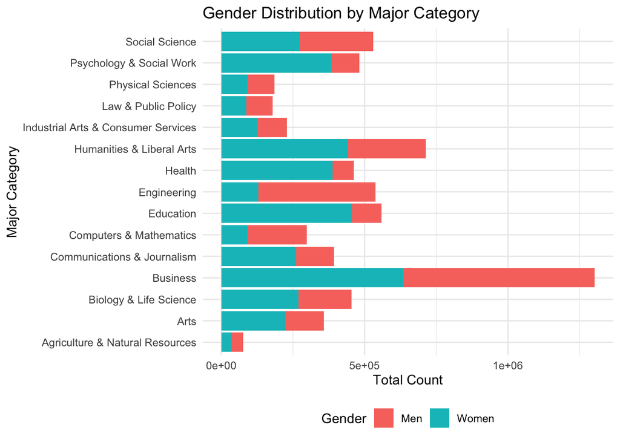

```r
# Filter out the "Interdisciplinary" category
filtered_gender_summary <- gender_summary %>%
  filter(Major_category != "Interdisciplinary")

# Reshape data to long format for stacked bar chart
gender_totals_long <- filtered_gender_summary %>%
  pivot_longer(cols = c(Sum_Men, Sum_Women), names_to = "Gender", values_to = "Count") %>%
  mutate(Gender = factor(Gender, levels = c("Sum_Men", "Sum_Women"), labels = c("Men", "Women")))

ggplot(gender_totals_long, aes(x = Count, y = Major_category, fill = Gender)) +
  geom_bar(stat = "identity") +
  labs(
    title = "Gender Distribution by Major Category",
    x = "Total Count",
    y = "Major Category",
    fill = "Gender"
  ) +
 theme_minimal() +
  theme(legend.position = "bottom")
```

The bar plot further visualizes the gender disparity among the departments as discussed above. This analysis highlights ongoing gender imbalances across different fields, with certain areas like STEM remaining male-dominated and others like Education and Health showing strong female representation. This distribution suggests that while some fields have achieved near parity, others continue to reflect traditional gender roles, which can influence career choices, income potential, and workforce diversity.

## 5. Inference

### 5.1 Hypothesis Testing

### 5.1.1 Two-Sample t-Test on Earnings Based on Gender

Gender pay disparity is a common topic of study in labor economics. Here male-dominated majors are defined by majors where the percentage of male graduates is 60% or higher and vice versa for female-dominated majors.

```r
# thresholds for gender
male_dominated_threshold <- 0.60
female_dominated_threshold <- 0.60
```

Research Question: Do male-dominated majors have significantly higher median earnings compared to female-dominated majors?

Null Hypothesis (H0): The mean of median earnings of male-dominated majors are equal to the mean of median earnings of female-dominated majors.

Alternative Hypothesis (H1): The mean of median earnings of male-dominated majors are higher than those of female-dominated majors.

Test Statistic: Since we would be comparing the means of two independent samples (male-dominated vs. female-dominated majors), we use the two-sample t-test. It is defined by the equation:

$$t = \frac{\bar{x}_1 - \bar{x}_2}{\sqrt{\frac{s_1^2}{n_1} +
\frac{s_2^2}{n_2}}}$$

Here x bar is the mean sample, s is the sample variance and n is the same size.

```r
# Filter male-dominated and female-dominated majors
male_dominated <- indata %>% filter(ShareWomen < (1 - male_dominated_threshold))
female_dominated <- indata %>% filter(ShareWomen > female_dominated_threshold)

# Median earnings
male_medians <- male_dominated$Median
female_medians <- female_dominated$Median

# sample statistics
mean_male <- mean(male_medians, na.rm = TRUE)
mean_male
```

```
## [1] 49376.36
```

```r
mean_female <- mean(female_medians, na.rm = TRUE)
mean_female
```

```
## [1] 33362.5
```

```r
var_male <- var(male_medians, na.rm = TRUE)
var_male
```

```
## [1] 184286653
```

```r
var_female <- var(female_medians, na.rm = TRUE)
var_female
```

```
## [1] 26821532
```

```r
n_male <- length(male_medians)
n_female <- length(female_medians)

# t-statistic
t_statistic <- (mean_male - mean_female) / sqrt((var_male / n_male) + (var_female / n_female))
t_statistic
```

```
## [1] 8.299246
```

```r
# degrees of freedom
df <- ((var_male / n_male + var_female / n_female)^2) /
      ((var_male / n_male)^2 / (n_male - 1) + (var_female / n_female)^2 / (n_female - 1))

# critical t-value for one-tailed test at alpha = 0.05
alpha <- 0.05
t_critical <- qt(1 - alpha, df)
t_critical
```

```
## [1] 1.668251
```

```r
p_value <- pt(t_statistic, df, lower.tail = FALSE)
p_value
```

```
## [1] 3.836875e-12
```

This can also be done easily using the built in function

```r
# Perform one-tailed two-sample t-test
t_test_result <- t.test(male_medians, female_medians, alternative = "greater", var.equal = FALSE)

t_test_result
```

```
##
##  Welch Two Sample t-test
##
## data:  male_medians and female_medians
## t = 8.2992, df = 66.054, p-value = 3.837e-12
## alternative hypothesis: true difference in means is greater than 0
## 95 percent confidence interval:
##  12794.88      Inf
## sample estimates:
## mean of x mean of y
##  49376.36  33362.50
```

The sample means and variances were calculated and used to calculate the t statistic as the reference distribution for the hypothesis test is the t-distribution.

We set a confidence level of 95% or in other words a 5% margin. The rejection criteria depends on the significance level (α=0.05) for the one-tailed test (testing whether male-dominated majors have higher earnings).

The critical t-value is the threshold value that separates the “rejection region” from the “non-rejection region” in the t-distribution. The p-value is the shaded area under the curve beyond the test statistic in the tail of the distribution. The calculated t-value (8.2992) is greater than the critical t-value (1.668) and p-value (3.8e-12) is significantly lower than alpha (0.05). Hence we reject the null hypothesis.

### 5.1.2 Two-Sample t-Test on Earnings Based on Major Categories (STEM vs. Non-STEM Majors)

```r
stem_categories <- c("Engineering", "Physical Sciences", "Biology & Life Science", "Mathematics & Computer Science, Health")

# Filter STEM and non-STEM majors
stem_data <- indata %>% filter(Major_category %in% stem_categories)
non_stem_data <- indata %>% filter(!(Major_category %in% stem_categories))
```

Research Question: Do STEM majors have significantly higher median earnings compared to non-STEM majors?

Null Hypothesis (H0): The mean of median earnings of STEM majors is equal to the mean of median earnings of non-STEM majors.

Alternative Hypothesis (H1): The mean of median earnings of STEM majors is greater than the mean of median earnings of non-STEM majors.

Test Statistic: Since we would be comparing the means of two independent samples (STEM majors vs. non-STEM majors), we use the two-sample t-test.

```r
# Median earnings for STEM and non-STEM majors
stem_medians <- stem_data$Median
non_stem_medians <- non_stem_data$Median

# Sample statistics
mean_stem <- mean(stem_medians, na.rm = TRUE)
mean_stem
```

```
## [1] 48922.64
```

```r
mean_non_stem <- mean(non_stem_medians, na.rm = TRUE)
mean_non_stem
```

```
## [1] 36136.97
```

```r
var_stem <- var(stem_medians, na.rm = TRUE)
var_non_stem <- var(non_stem_medians, na.rm = TRUE)
n_stem <- length(stem_medians)
n_non_stem <- length(non_stem_medians)

# t-statistic calculation
t_statistic <- (mean_stem - mean_non_stem) / sqrt((var_stem / n_stem) + (var_non_stem / n_non_stem))
t_statistic
```

```
## [1] 6.142252
```

```r
df <- ((var_stem / n_stem + var_non_stem / n_non_stem)^2) /
  ((var_stem / n_stem)^2 / (n_stem - 1) + (var_non_stem / n_non_stem)^2 / (n_non_stem - 1))


# Critical t-value for one-tailed test at alpha = 0.05
alpha <- 0.05
t_critical <- qt(1 - alpha, df)
t_critical
```

```
## [1] 1.669457
```

```r
# p-value calculation
p_value <- pt(t_statistic, df, lower.tail = FALSE)
p_value
```

```
## [1] 3.057248e-08
```

The calculated t-statistic is 6.142, which measures how far the sample means are from each other in units of the standard error. This high t-value suggests a significant difference between the group means. The critical t-value is 1.669 for a one-tailed test with a significance level (alpha = 0.05), i.e confidence level of 95%.

The critical value indicates the threshold above which we reject the null hypothesis. As the calculated t-statistic is significantly greater than the critical t-value of 1.669, in addition to the p-value (3.057e-08) being much smaller than the significance level of 0.05, we have strong evidence to reject the null hypothesis.

### 5.2 Linear Regression

### 5.2.1 Unemployment Rate vs Median Salary

Understanding the relationship between median salary and unemployment rate can provide valuable insights into the economic outcomes of various majors. This analysis examines whether median salary serves as a significant predictor of unemployment rate using a linear regression approach. By assessing the strength, direction, and statistical significance of this relationship, we aim to determine whether higher median salaries correlate with lower unemployment rates or if other factors might play a more dominant role.

```r
# variables
X_median <- indata$Median
y_unemployment_rate <- indata$Unemployment_rate

(lm.fit <- lm(y_unemployment_rate ~ X_median, data = indata))
```

```
##
## Call:
## lm(formula = y_unemployment_rate ~ X_median, data = indata)
##
## Coefficients:
## (Intercept)     X_median
##   8.031e-02   -3.065e-07
```

The above function provides the coefficients for the linear regression model: $y = \beta_0 + \beta_1 x$

The estimated intercept is 0.08 which represents the predicted unemployment rate when the median salary is zero. This value is not logically meaningful as median salary won’t be going to 0 and graduates would not be interested to work with a salary of 0.

The estimated slope is -3.065e-07, which indicates the change in unemployment rate for a increase in median salary is negligible and as salary goes up, unemployment rate decreases.

The linear regression equation can be represented by Unemployment_rate = 0.08 + -3.065e-07 * Median

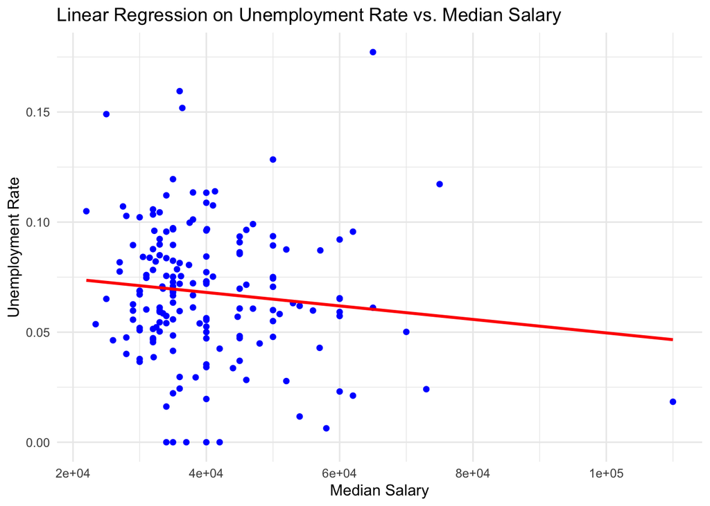

```r
# Visualize regression line
ggplot(indata, aes(x = Median, y = Unemployment_rate)) +
  geom_point(color = "blue") + geom_smooth(method = "lm", color = "red", se = FALSE) +
  labs(title = "Linear Regression on Unemployment Rate vs. Median Salary",
    x = "Median Salary",
    y = "Unemployment Rate") +theme_minimal()
```

The plot with the regression line further visualizes the negative, low slope calculated above.

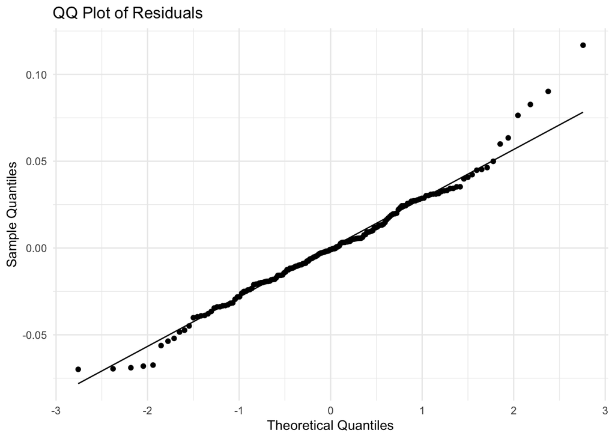

```r
# QQ plot of residuals
fit_residuals <- lm.fit$residuals %>%
  as.data.frame()
fit_residuals %>%
  ggplot(aes(sample = lm.fit$residuals)) + stat_qq(distribution = stats::qnorm) +
  stat_qq_line() + labs( title = "QQ Plot of Residuals",x = "Theoretical Quantiles",y = "Sample Quantiles")+ theme_minimal()
```

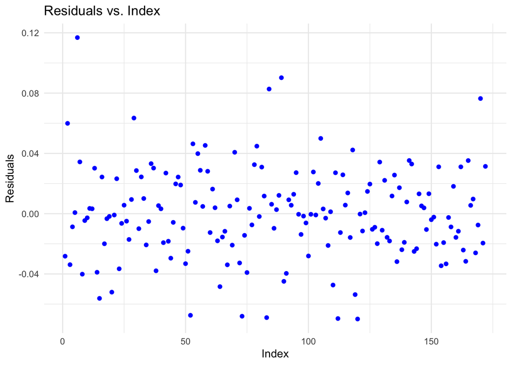

```r
# Residuals vs. Index Plot
fit_residuals$Index <- 1:nrow(fit_residuals)
ggplot(fit_residuals, aes(x = Index, y = lm.fit$residuals)) + geom_point(color = "blue") +
  labs(
    title = "Residuals vs. Index",
    x = "Index",
    y = "Residuals"
  ) +theme_minimal()
```

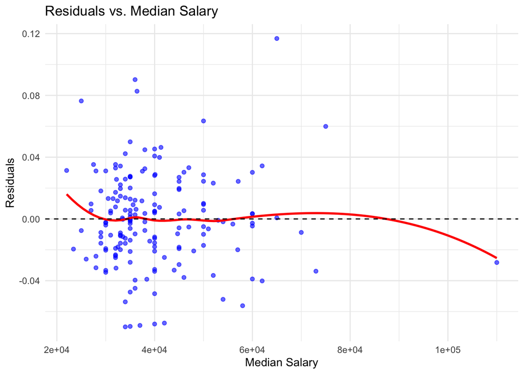

```r
ggplot(data = indata, aes(x = X_median, y = residuals(lm.fit))) +
  geom_point(color = "blue", alpha = 0.6) +
  geom_smooth(method = "loess", color = "red", se = FALSE) +
  geom_hline(yintercept = 0, linetype = "dashed", color = "black") +
  labs(
    title = "Residuals vs. Median Salary",
    x = "Median Salary",
    y = "Residuals"
  ) +theme_minimal()
```

This plot visualizes the residuals (differences between observed and predicted unemployment rates) against the independent variable, Median Salary. The residuals are spread around the horizontal dashed line at y=0. However, there is a slight curved shape in the residuals indicating non-linearity. The red LOESS (Locally Estimated Scatterplot Smoothing) curve shows a slight downward curve at the edges, deviating from zero. This suggests that the model may not fully capture the relationship between median salary and unemployment rate.

```r
confint(lm.fit)
```

```
##                     2.5 %       97.5 %
## (Intercept)  6.371577e-02 9.689498e-02
## X_median    -7.045310e-07 9.162469e-08
```

The above function calculates confidence intervals for the coefficients of a linear regression model. In this case, the 95% confidence intervals for the intercept and slope (X_median) are provided.

```r
summary(lm.fit)
```

```
##
## Call:
## lm(formula = y_unemployment_rate ~ X_median, data = indata)
##
## Residuals:
##       Min        1Q    Median        3Q       Max
## -0.069886 -0.019075 -0.000885  0.019174  0.116840
##
## Coefficients:
##               Estimate Std. Error t value Pr(>|t|)
## (Intercept)  8.031e-02  8.404e-03   9.556   <2e-16 ***
## X_median    -3.065e-07  2.017e-07  -1.520     0.13
## ---
## Signif. codes:  0 '***' 0.001 '**' 0.01 '*' 0.05 '.' 0.1 ' ' 1
##
## Residual standard error: 0.03022 on 170 degrees of freedom
## Multiple R-squared:  0.0134, Adjusted R-squared:  0.007599
## F-statistic: 2.309 on 1 and 170 DF,  p-value: 0.1305
```

The residual quartlie values summarize the distribution of residuals.

The t values from the t statistic is also provided above.

Here the null hypothesis (H0) is X_median(slope) = 0 and alternate hypothesis (H1) is X_median is not equals to 0.

Although the residual error is small (0.03022), it doesn’t mean a better fit. It must be interpreted relative to the scale of the dependent variable and unemployment rates are all low in the dataset.

The Multiple R-squared value is 0.0134, which means the model explains only 1.34% of the variance in unemployment rate, indicating a very weak relationship. Similarly the low adjusted R score refer to a poor relation.

## 6. Conclusion

Hypothesis testing confirmed that male-dominated and STEM majors tend to have significantly higher earnings. However, linear regression revealed a weak and statistically insignificant relationship between median salary and unemployment rate, suggesting that factors beyond salary influence job stability.